# Prediction of 31-10-2020 revenue of ULTA dataset

I will use 3 different approaches and then compare the results:

- SARIMA
- Linear regression
- Recurrent Neural Network (LSTM)

```python
import pandas as pd
import numpy as np
import seaborn as sns
import itertools
import matplotlib.pyplot as plt
import sys
import statsmodels.api as sm

import warnings
warnings.filterwarnings('ignore')
```

## Explore data

```python
df = pd.read_csv("../input/my-ulta/ULTA data (1).csv",engine="python")
```

```python
df
```

|  | Period Ending | Quarter | Revenue | COGS | GrossProfit | NetIncome | DilutedEPS | Inventory | Unemployment | RetailSales | ... | search 2 US | search 3 US | search 4 US | IG Likes | IG Comments | IG posts | web avg rank (Global) | Web Traffic Total\n(US) | Web Traffic Organic\n(US) | Web Traffic Paid\n(US) |
| --- | --- | --- | --- | --- | --- | --- | --- | --- | --- | --- | --- | --- | --- | --- | --- | --- | --- | --- | --- | --- | --- |
| 0 | 30/04/2016 | 1.0 | 1,315 | 839 | 476.03 | 128.22 | 2.05 | 843.0 | 4.97 | 112.59 | ... | NaN | 2.3 | 2.3 | NaN | NaN | NaN | NaN | NaN | NaN | NaN |
| 1 | 31/07/2016 | 2.0 | 1,290 | 821 | 469.36 | 114.26 | 1.83 | 930.0 | 4.83 | 114.47 | ... | 1.0 | 2.2 | 2.3 | NaN | NaN | NaN | NaN | NaN | NaN | NaN |
| 2 | 31/10/2016 | 3.0 | 1,342 | 849 | 493.13 | 104.67 | 1.70 | 1137.0 | 4.93 | 115.12 | ... | 1.0 | 2.5 | 2.1 | NaN | NaN | NaN | NaN | NaN | NaN | NaN |
| 3 | 31/01/2017 | 4.0 | 1,938 | 1,275 | 662.41 | 168.71 | 2.75 | 944.0 | 4.70 | 116.70 | ... | 1.1 | 4.2 | 3.1 | NaN | NaN | NaN | NaN | NaN | NaN | NaN |
| 4 | 30/04/2017 | 1.0 | 1,315 | 839 | 476.03 | 128.22 | 2.05 | 1048.0 | 4.53 | 117.36 | ... | 1.6 | 3.6 | 2.0 | NaN | NaN | NaN | NaN | NaN | NaN | NaN |
| 5 | 31/07/2017 | 2.0 | 1,290 | 821 | 469.36 | 114.26 | 1.83 | 1145.0 | 4.33 | 117.31 | ... | 2.0 | 3.2 | 2.5 | NaN | NaN | NaN | NaN | NaN | NaN | NaN |
| 6 | 31/10/2017 | 3.0 | 1,342 | 849 | 493.13 | 104.67 | 1.70 | 1350.0 | 4.23 | 118.80 | ... | 2.0 | 4.3 | 2.6 | NaN | NaN | NaN | NaN | NaN | NaN | NaN |
| 7 | 31/01/2018 | 4.0 | 1,938 | 1,275 | 662.41 | 168.71 | 2.75 | 1096.0 | 4.10 | 120.74 | ... | 2.2 | 5.5 | 3.6 | NaN | NaN | NaN | 3,257 | NaN | NaN | NaN |
| 8 | 30/04/2018 | 1.0 | 1,544 | 983 | 560.71 | 164.47 | 2.70 | 1137.0 | 4.03 | 121.15 | ... | 1.2 | 4.9 | 2.7 | NaN | NaN | NaN | 2,699 | NaN | NaN | NaN |
| 9 | 31/07/2018 | 2.0 | 1,488 | 953 | 535.46 | 148.33 | 2.46 | 1220.0 | 3.90 | 123.22 | ... | 2.3 | 4.0 | 2.5 | NaN | NaN | NaN | 3,444 | NaN | NaN | NaN |
| 10 | 31/10/2018 | 3.0 | 1,560 | 988 | 572.27 | 131.16 | 2.18 | 1485.0 | 3.77 | 124.37 | ... | 3.0 | 4.6 | 2.6 | NaN | NaN | NaN | 3,447 | NaN | NaN | NaN |
| 11 | 31/01/2019 | 4.0 | 2,125 | 1,384 | 740.86 | 214.68 | 3.61 | 1214.0 | 3.87 | 125.27 | ... | 3.1 | 6.4 | 3.5 | 4,932,619 | 70,438 | 177.0 | 3,257 | NaN | NaN | NaN |
| 12 | 30/04/2019 | 1.0 | 1,743 | 1,098 | 644.85 | 192.22 | 3.26 | 1250.0 | 3.73 | 133.95 | ... | 1.9 | 5.6 | 2.1 | 4,919,119 | 81,171 | 175.0 | 2,785 | 73,689,480 | 71,464,570 | 2,224,910 |
| 13 | 31/07/2019 | 2.0 | 1,667 | 1,061 | 605.90 | 161.27 | 2.76 | 1316.0 | 3.67 | 147.63 | ... | 3.2 | 5.5 | 2.2 | 3,910,190 | 106,143 | 186.0 | 3,314 | 71,508,620 | 68,286,434 | 3,222,186 |
| 14 | 31/10/2019 | 3.0 | 1,683 | 1,059 | 623.43 | 129.75 | 2.25 | 1617.0 | 3.60 | 164.95 | ... | 3.3 | 6.3 | 2.1 | 3,849,829 | 75,675 | 184.0 | 3,765 | 67,357,123 | 63,611,384 | 3,745,739 |
| 15 | 31/01/2020 | 4.0 | 2,306 | 1,499 | 806.89 | 222.72 | 3.89 | 1294.0 | 3.53 | 186.05 | ... | 3.9 | 7.8 | 3.4 | 3,184,218 | 52,102 | 178.0 | 3,257 | 85,235,695 | 81,589,978 | 3,645,717 |
| 16 | 30/04/2020 | 1.0 | 1,173 | 870 | 303.61 | -78.51 | -1.39 | 1341.0 | 7.53 | 183.01 | ... | 2.2 | 5.3 | 2.0 | 2,944,461 | 45,167 | 174.0 | 3,807 | 83,836,420 | 80,705,529 | 3,130,891 |
| 17 | 31/07/2020 | 2.0 | 1,228 | 899 | 329.01 | 41.31 | 0.73 | 1369.0 | 11.53 | 144.16 | ... | 3.2 | 6.4 | 2.0 | 2,015,984 | 27,984 | 134.0 | 3,580 | 87,084,407 | 83,309,219 | 3,775,188 |
| 18 | 31/10/2020 | 3.0 | NaN | NaN | NaN | NaN | NaN | NaN | 8.15 | 155.14 | ... | 2.9 | 5.7 | 1.9 | 1,636,135 | 22,374 | 162.0 | 3,067 | 91,630,322 | 87,074,996 | 4,555,326 |
| 19 | NaN | NaN | NaN | NaN | NaN | NaN | NaN | NaN | NaN | NaN | ... | NaN | NaN | NaN | NaN | NaN | NaN | NaN | NaN | NaN | NaN |
| 20 | NaN | NaN | NaN | NaN | NaN | NaN | NaN | NaN | NaN | NaN | ... | NaN | NaN | NaN | NaN | NaN | NaN | NaN | NaN | NaN | NaN |
| 21 | NaN | NaN | NaN | NaN | NaN | NaN | NaN | NaN | NaN | NaN | ... | NaN | NaN | NaN | NaN | NaN | NaN | NaN | NaN | NaN | NaN |
| 22 | NaN | NaN | NaN | NaN | NaN | NaN | NaN | NaN | NaN | NaN | ... | NaN | NaN | NaN | NaN | NaN | NaN | NaN | NaN | NaN | NaN |
| 23 | NaN | NaN | NaN | NaN | NaN | NaN | NaN | NaN | NaN | NaN | ... | NaN | NaN | NaN | NaN | NaN | NaN | NaN | NaN | NaN | NaN |

24 rows × 36 columns

The value to be predicted is the Revenue at 31-10-2020. From the dataset we can see that the values of some other features for the 31-10-2020 data point are known. Therefore, in the following I will distinguish between two different situations:

- A) Prediction using NO information from 31-10-2020
- B) Prediction USING information from 31-10-2020

I will show results with both approaches, so that the procedures can be applied also to different real-life situations, depending on what data are known.

```python
df.info()
```

- Removing last rows with no data and last columns with many null values
- Set date as index
- Convert string columns into float

```python
df.drop(df.loc[:3].index,inplace=True) #remove 2016 data
df.drop(df.loc[19:].index,inplace=True)
df.drop(df.loc[:, 'IG Likes':].columns,axis=1,inplace=True)
```

```python
df['Date'] = pd.to_datetime(df[' Period Ending '])
df = df.set_index('Date')
df.drop([' Period Ending '],axis=1,inplace=True)
```

```python
df.drop(df.loc[:, ' COGS ':'Inventory'].columns,axis=1,inplace=True)
df.drop(['FloorSpace'],axis=1,inplace=True)
```

```python
df['COVID19'] = df['COVID19'].apply(lambda x: float(x.replace(' ','').replace(',','')))
df['WallSt'] = df['WallSt'].apply(lambda x: float(x.replace(' ','').replace(',','')))
df['WallStHigh'] = df['WallStHigh'].apply(lambda x: float(x.replace(' ','').replace(',','')))
df['WallStLow'] = df['WallStLow'].apply(lambda x: float(x.replace(' ','').replace(',','')))
```

```python
df.info()
```

```
<class 'pandas.core.frame.DataFrame'>
DatetimeIndex: 15 entries, 2017-04-30 to 2020-10-31
Data columns (total 22 columns):
 #   Column             Non-Null Count  Dtype
---  ------             --------------  -----
 0    Quarter           15 non-null     float64
 1    Revenue           14 non-null     object
 2   Unemployment       15 non-null     float64
 3   RetailSales        15 non-null     float64
 4   PMI                15 non-null     float64
 5   GDP                15 non-null     float64
 6   FedInterest        15 non-null     float64
 7   MichiganCS         15 non-null     float64
 8   StockPrice         15 non-null     float64
 9   ShopCount          15 non-null     float64
 10  COVID19            15 non-null     float64
 11  WallSt             15 non-null     float64
 12  WallStHigh         15 non-null     float64
 13  WallStLow          15 non-null     float64
 14   Search 1 global   15 non-null     float64
 15   search 2 global   15 non-null     float64
 16   search 3 global   15 non-null     float64
 17   search 4 global   15 non-null     float64
 18   search 1 US       15 non-null     float64
 19  search 2 US        15 non-null     float64
 20  search 3 US        15 non-null     float64
 21  search 4 US        15 non-null     float64
dtypes: float64(21), object(1)
memory usage: 2.7+ KB
```

## Approach 1: univariate time series forecast using SARIMA

ARIMA is a forecasting method for univariate time series data. SARIMA (Seasonal ARIMA) is an extension of ARIMA to support univariate time series data with seasonal component.

SARIMA is used on univariate time series, so for the moment we will only consider the column "revenue" and drop all the others.

#### This case falls under situation A (Prediction using NO information from 31-10-2020)

```python
df_train = df[:'2020-07-31'] #remove the last data point (the one we want to forecast)
df_train['Revenue'] = df_train[' Revenue '].apply(lambda x: float(x.replace(' ','').replace(',','')))
df_train.drop([' Revenue '],axis=1,inplace=True)
#df_train = df_train[['Revenue']]
```

```python
y = df_train['Revenue']
y
```

```
Date
2017-04-30    1315.0
2017-07-31    1290.0
2017-10-31    1342.0
2018-01-31    1938.0
2018-04-30    1544.0
2018-07-31    1488.0
2018-10-31    1560.0
2019-01-31    2125.0
2019-04-30    1743.0
2019-07-31    1667.0
2019-10-31    1683.0
2020-01-31    2306.0
2020-04-30    1173.0
2020-07-31    1228.0
Name: Revenue, dtype: float64
```

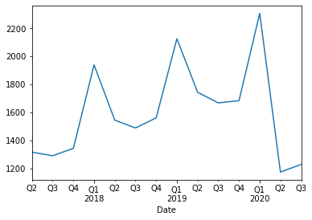

```python
y.plot()
```

We can notice immediately that the series has a "regular pattern" until end of 2019, then it deviates significantly - this is due to the COVID crisis.

### Decompose data to check the seasonal trend

From the plots, we see the data is not stationary, since there is an upward trend - however this is not a problem since SARIMAX model can takes this into account

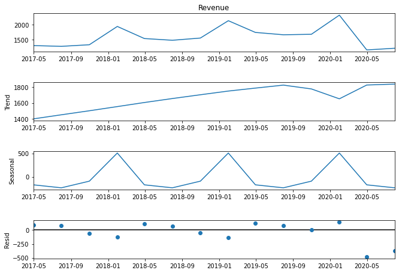

```python
decomposition = sm.tsa.seasonal_decompose(y, model='additive',extrapolate_trend='freq')
fig = decomposition.plot()
fig.set_size_inches(10,7)
plt.show()
```

The magnitude of the seasonal component is constant over time, so we can infer that our model will be additive.

### Grid search

The SARIMA model includes several parameters:

SARIMA(p,d,q)(P,D,Q)m

(p,d,q) are the trend elements, where

- p is the trend autoregressive order (the number of time lags)
- d is the trend difference order (the number of times the data have had past values subtracted)
- q is the order of the moving-average model

(P,D,Q)m are the seasonal elements, where

- P is the seasonal autoregressive order
- D is the seasonal difference order
- Q is the order of the seasonal moving-average model
- m is the number of steps for each seasonal period

in our case, m = 4, since we have 4 quarters in one year. The other parameters can be found using a grid search. The metric used in the grid search is the AIC (Akaike Information Criterion) value, which measures how well the model fits the data while taking into account the overall complexity of the model. We will take the combination of parameters with lowest AIC:

```python
def sarima_grid_search(y,seasonal_period,exog=None):
    p = range(0, 3)
    d = range(1, 2)
    q = range(0, 3)
    pdq = list(itertools.product(p, d, q))
    seasonal_pdq = [(x[0], x[1], x[2],seasonal_period) for x in list(itertools.product(p, d, q))]

    mini = float('+inf')


    for param in pdq:
        for param_seasonal in seasonal_pdq:
            try:
                mod = sm.tsa.statespace.SARIMAX(y,exog=exog,
                                                order=param,
                                                seasonal_order=param_seasonal,
                                                enforce_stationarity=True,
                                                enforce_invertibility=True)

                results = mod.fit()

                if results.aic < mini:
                    mini = results.aic
                    param_mini = param
                    param_seasonal_mini = param_seasonal

                print('SARIMA{}x{} - AIC:{}'.format(param, param_seasonal, results.aic))
            except:
                continue
    print('The set of parameters with the minimum AIC is: SARIMA{}x{} - AIC:{}'.format(param_mini, param_seasonal_mini, mini))
```

```python
sarima_grid_search(y,4)
```

```
SARIMA(0, 1, 0)x(0, 1, 0, 4) - AIC:127.36482479384848
SARIMA(0, 1, 0)x(0, 1, 1, 4) - AIC:129.3554291972328
SARIMA(0, 1, 0)x(0, 1, 2, 4) - AIC:130.01064281317105
SARIMA(0, 1, 0)x(1, 1, 0, 4) - AIC:129.34903039108497
SARIMA(0, 1, 0)x(1, 1, 1, 4) - AIC:131.02481309300188
SARIMA(0, 1, 0)x(1, 1, 2, 4) - AIC:131.98868897805647
SARIMA(0, 1, 0)x(2, 1, 0, 4) - AIC:35047124028.12345
SARIMA(0, 1, 0)x(2, 1, 1, 4) - AIC:131.16019222638485
SARIMA(0, 1, 0)x(2, 1, 2, 4) - AIC:133.16993549053723
SARIMA(0, 1, 1)x(0, 1, 0, 4) - AIC:128.9294474359307
SARIMA(0, 1, 1)x(0, 1, 1, 4) - AIC:130.92725873745746
SARIMA(0, 1, 1)x(0, 1, 2, 4) - AIC:131.6160913777447
SARIMA(0, 1, 1)x(1, 1, 0, 4) - AIC:130.9257988020848
SARIMA(0, 1, 1)x(1, 1, 1, 4) - AIC:132.66461727847303
SARIMA(0, 1, 1)x(1, 1, 2, 4) - AIC:133.61812474810185
SARIMA(0, 1, 1)x(2, 1, 0, 4) - AIC:130.81680163534145
SARIMA(0, 1, 1)x(2, 1, 1, 4) - AIC:132.85741167418468
SARIMA(0, 1, 1)x(2, 1, 2, 4) - AIC:134.8229301887126
SARIMA(0, 1, 2)x(0, 1, 0, 4) - AIC:131.48376870908763
SARIMA(0, 1, 2)x(0, 1, 1, 4) - AIC:135.21977561569054
SARIMA(0, 1, 2)x(0, 1, 2, 4) - AIC:138.4791326527686
SARIMA(0, 1, 2)x(1, 1, 0, 4) - AIC:133.2655807164851
SARIMA(0, 1, 2)x(1, 1, 1, 4) - AIC:135.48385389180808
SARIMA(0, 1, 2)x(1, 1, 2, 4) - AIC:139.22006428159932
SARIMA(0, 1, 2)x(2, 1, 0, 4) - AIC:134.34638792938208
SARIMA(0, 1, 2)x(2, 1, 1, 4) - AIC:137.33074714644198
SARIMA(0, 1, 2)x(2, 1, 2, 4) - AIC:138.3076661609208
SARIMA(1, 1, 0)x(0, 1, 0, 4) - AIC:128.87347249745312
SARIMA(1, 1, 0)x(0, 1, 1, 4) - AIC:130.8717781874815
SARIMA(1, 1, 0)x(0, 1, 2, 4) - AIC:131.56641736622214
SARIMA(1, 1, 0)x(1, 1, 0, 4) - AIC:130.87065974614484
SARIMA(1, 1, 0)x(1, 1, 1, 4) - AIC:132.61667369205875
SARIMA(1, 1, 0)x(1, 1, 2, 4) - AIC:133.5649657593621
SARIMA(1, 1, 0)x(2, 1, 0, 4) - AIC:130.7639170010599
SARIMA(1, 1, 0)x(2, 1, 1, 4) - AIC:132.8011205709594
SARIMA(1, 1, 0)x(2, 1, 2, 4) - AIC:134.75905694848333
SARIMA(1, 1, 1)x(0, 1, 0, 4) - AIC:130.8384694742453
SARIMA(1, 1, 1)x(0, 1, 1, 4) - AIC:132.83474634129516
SARIMA(1, 1, 1)x(0, 1, 2, 4) - AIC:133.54960585980615
SARIMA(1, 1, 1)x(1, 1, 0, 4) - AIC:132.83213534769783
```

[output cut: 23 more lines]

```
SARIMA(2, 1, 1)x(0, 1, 0, 4) - AIC:132.67291882688983
SARIMA(2, 1, 1)x(0, 1, 2, 4) - AIC:142.82338764581752
SARIMA(2, 1, 1)x(1, 1, 2, 4) - AIC:144.21254197113282
SARIMA(2, 1, 1)x(2, 1, 0, 4) - AIC:134.7599108306531
SARIMA(2, 1, 1)x(2, 1, 1, 4) - AIC:136.78341627790627
SARIMA(2, 1, 1)x(2, 1, 2, 4) - AIC:138.6004448699788
SARIMA(2, 1, 2)x(0, 1, 0, 4) - AIC:35047129979.25938
SARIMA(2, 1, 2)x(0, 1, 1, 4) - AIC:35047129936.59834
SARIMA(2, 1, 2)x(0, 1, 2, 4) - AIC:35047129938.8678
SARIMA(2, 1, 2)x(1, 1, 0, 4) - AIC:35047129936.61278
SARIMA(2, 1, 2)x(1, 1, 1, 4) - AIC:35047129893.95176
SARIMA(2, 1, 2)x(2, 1, 0, 4) - AIC:35047129938.88541
SARIMA(2, 1, 2)x(2, 1, 1, 4) - AIC:35047129896.22432
SARIMA(2, 1, 2)x(2, 1, 2, 4) - AIC:35047129898.49382
The set of parameters with the minimum AIC is: SARIMA(0, 1, 0)x(0, 1, 0, 4) - AIC:127.36482479384848
```

### Prediction

First, we use the model to predict the last 4 data points of our dataset, comparing them with the observed value - this is a test to check how good our model is.

```python
def sarima_eva(y,order,seasonal_order,seasonal_period,pred_date,exog=None):
    # fit the model
    mod = sm.tsa.statespace.SARIMAX(y,exog=exog,
                                order=order,
                                seasonal_order=seasonal_order,
                                enforce_stationarity=True,
                                enforce_invertibility=True)

    results = mod.fit()

    # One-step ahead forecast: forecasts at each point are generated using the full history
    #up to that point.
    pred = results.get_prediction(start=pd.to_datetime(pred_date), dynamic=False)
    pred_ci = pred.conf_int()
    y_forecasted = pred.predicted_mean
    print(f"PREDICTED: \n{y_forecasted}")
    mse = ((y_forecasted - y) ** 2).mean()
    print('Root Mean Squared Error of SARIMA with season_length={} and dynamic = False : {}'.format(seasonal_period,round(np.sqrt(mse), 2)))

    ax = y.plot(label='observed')
    y_forecasted.plot(ax=ax, label='One-step ahead Forecast', alpha=.7, figsize=(14, 7))
    ax.fill_between(pred_ci.index,
                    pred_ci.iloc[:, 0],
                    pred_ci.iloc[:, 1], color='k', alpha=.2)

    ax.set_xlabel('Date')
    ax.set_ylabel('Sessions')
    plt.legend()
    plt.show()

    # Dynamic forecast: use information from the time series up to a certain point,
    # and after that, forecasts are generated using values from previous forecasted time points.
    pred_dynamic = results.get_prediction(start=pd.to_datetime(pred_date), dynamic=True, full_results=True)
    pred_dynamic_ci = pred_dynamic.conf_int()
    y_forecasted_dynamic = pred_dynamic.predicted_mean
    mse_dynamic = ((y_forecasted_dynamic - y) ** 2).mean()
    print('Root Mean Squared Error of SARIMA with season_length={} and dynamic = True : {} :'.format(seasonal_period,round(np.sqrt(mse_dynamic), 2)))

    ax = y.plot(label='observed')
    y_forecasted_dynamic.plot(label='Dynamic Forecast', ax=ax,figsize=(14, 7))
    ax.fill_between(pred_dynamic_ci.index,
                    pred_dynamic_ci.iloc[:, 0],
                    pred_dynamic_ci.iloc[:, 1], color='k', alpha=.2)

    ax.set_xlabel('Date')
    ax.set_ylabel('Sessions')

    plt.legend()
    plt.show()

    return (results)
```

```
PREDICTED:
2019-10-31    1739.0
2020-01-31    2248.0
2020-04-30    1924.0
2020-07-31    1097.0
Freq: Q-OCT, dtype: float64
Root Mean Squared Error of SARIMA with season_length=4 and dynamic = False : 383.3
```

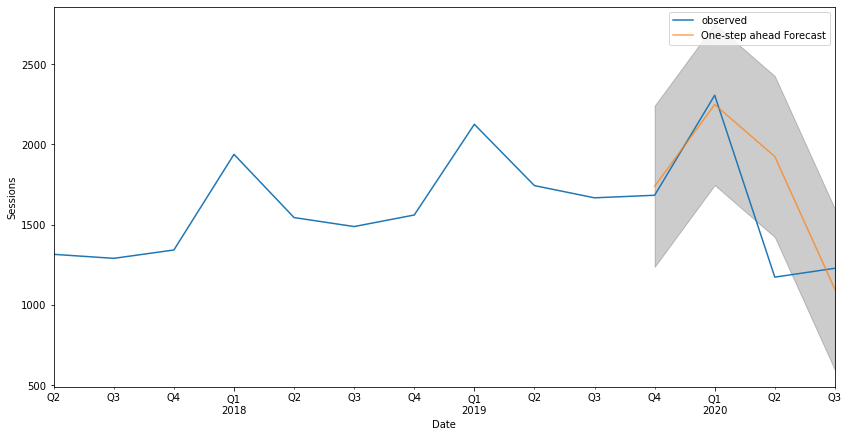

```
Root Mean Squared Error of SARIMA with season_length=4 and dynamic = True : 486.33 :
```

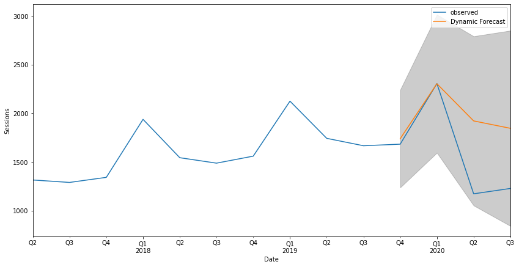

```python
#(0, 1, 0)x(0, 1, 0, 4)  #best parameters
model = sarima_eva(y,(0, 1, 0),(0, 1, 0, 4),4,'2019-10-31')
```

The model seems reliable at least in the prediction of the first 1-2 values into the future.

#### However, when the COVID situation starts, predictions become less reliable.

### Forecast of future values

Now we use the model to predict future values (in particular, we are interested on the 31-10-2020 data point):

```python
def forecast(model,y,predict_steps,exog=None):

    pred_uc = model.get_forecast(steps=predict_steps,exog=exog)

    #SARIMAXResults.conf_int, can change alpha,the default alpha = .05 returns a 95% confidence interval.
    pred_ci = pred_uc.conf_int()

    ax = y.plot(label='observed', figsize=(14, 7))
    pred_uc.predicted_mean.plot(ax=ax, label='Forecast')
    ax.fill_between(pred_ci.index,
                    pred_ci.iloc[:, 0],
                    pred_ci.iloc[:, 1], color='k', alpha=.25)
    ax.set_xlabel('Date')
    ax.set_ylabel(y.name)

    plt.legend()
    plt.show()

    # Produce the forcasted tables
    pm = pred_uc.predicted_mean.reset_index()
    pm.columns = ['Date','Predicted_Mean']
    pci = pred_ci.reset_index()
    pci.columns = ['Date','Lower Bound','Upper Bound']
    final_table = pm.join(pci.set_index('Date'), on='Date')

    return (final_table)
```

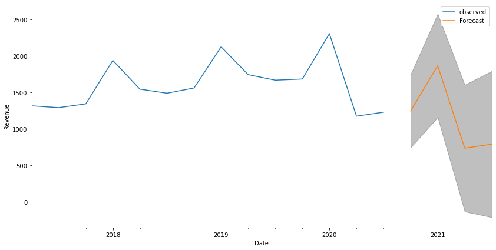

|  | Date | Predicted_Mean | Lower Bound | Upper Bound |
| --- | --- | --- | --- | --- |
| 0 | 2020-10-31 | 1244.0 | 742.090538 | 1745.909462 |
| 1 | 2021-01-31 | 1867.0 | 1157.192832 | 2576.807168 |
| 2 | 2021-04-30 | 734.0 | -135.332689 | 1603.332689 |
| 3 | 2021-07-31 | 789.0 | -214.818923 | 1792.818923 |

```python
final_table = forecast(model,y,4)
final_table.head()
```

The value predicted for the revenue for the 31-10-2020 data point is 1244.0 (C.I: 742-1746).

### Notes

These data presents a particular challenge: due to the COVID-19 crisis, the last 2 observed data points (April 2020 and July 2020) deviate significantly from the trend of the previous years (in particular, revenues are much lower). This makes the predictions into the future much less reliable (in fact, the uncertainty band is large), since the conditions of the time series changed significantly in 2020 and therefore the model cannot "extrapolate" them from the previous years.

## Approach 1b: include exogeneous variables into the model (SARIMAX)

One thing we can do to try to improve the predictions is to look at other variables. Here we want to predict Revenue for Q4 2020 (31-10-2020). For this data point, the value of other variables are also provided in the original file - this means that we can actually use them to improve the estimate.

#### This case falls under situation B (Prediction USING information from 31-10-2020)

By looking at the correlation of revenue with other variables, it seems that 'WallSt' (Wall Street Index) matches extremely well the 'Revenue' series:

```python
df[[' Revenue ','WallSt']]
```

| Date | Revenue | WallSt |
| --- | --- | --- |
| 2017-04-30 | 1,315 | 1275.0 |
| 2017-07-31 | 1,290 | 1285.0 |
| 2017-10-31 | 1,342 | 1344.0 |
| 2018-01-31 | 1,938 | 1942.0 |
| 2018-04-30 | 1,544 | 1518.0 |
| 2018-07-31 | 1,488 | 1490.0 |
| 2018-10-31 | 1,560 | 1559.0 |
| 2019-01-31 | 2,125 | 2109.0 |
| 2019-04-30 | 1,743 | 1747.0 |
| 2019-07-31 | 1,667 | 1679.0 |
| 2019-10-31 | 1,683 | 1690.0 |
| 2020-01-31 | 2,306 | 2324.0 |
| 2020-04-30 | 1,173 | 1199.0 |
| 2020-07-31 | 1,228 | 1236.0 |
| 2020-10-31 | NaN | 1552.0 |

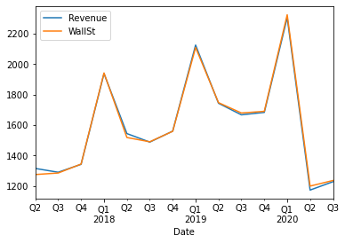

```python
df_train[['Revenue','WallSt']].plot()
```

The two series have almost 100% correlation - which means we can use 'WallSt' to predict the value of the Revenue for the missng data point, 31-10-2020.

In the SARIMA model, this can be done by adding the 'WallSt' as "exogeneous variable":

```python
df_train = df[:'2020-07-31'] #remove the last data point (the one we want to forecast)
df_train['Revenue'] = df_train[' Revenue '].apply(lambda x: float(x.replace(' ','').replace(',','')))
df_train.drop([' Revenue '],axis=1,inplace=True)
#df_train = df_train[['Revenue']]
y = df_train['Revenue']
```

```python
df_test = df['2020-10-31':]
exog_pred = df_train[['WallSt']] #this is the in-sample prediction
exog_for = df_test[['WallSt']] #this is for out-of-sample prediction
```

```python
sarima_grid_search(y,4,exog=exog_pred)
```

```
SARIMA(0, 1, 0)x(0, 1, 0, 4) - AIC:85.54382089007387
SARIMA(0, 1, 0)x(0, 1, 1, 4) - AIC:86.32864375485866
SARIMA(0, 1, 0)x(0, 1, 2, 4) - AIC:87.71274098460468
SARIMA(0, 1, 0)x(1, 1, 0, 4) - AIC:86.19432026242004
SARIMA(0, 1, 0)x(1, 1, 1, 4) - AIC:87.78451488127163
SARIMA(0, 1, 0)x(1, 1, 2, 4) - AIC:89.60320966839694
SARIMA(0, 1, 0)x(2, 1, 1, 4) - AIC:89.33730628272708
SARIMA(0, 1, 0)x(2, 1, 2, 4) - AIC:91.33753474285527
SARIMA(0, 1, 1)x(0, 1, 0, 4) - AIC:84.15497683778251
SARIMA(0, 1, 1)x(0, 1, 1, 4) - AIC:86.06769936432106
SARIMA(0, 1, 1)x(0, 1, 2, 4) - AIC:87.15888486574292
SARIMA(0, 1, 1)x(1, 1, 0, 4) - AIC:86.03446697609915
SARIMA(0, 1, 1)x(1, 1, 1, 4) - AIC:87.58781890699375
SARIMA(0, 1, 1)x(1, 1, 2, 4) - AIC:88.81572337189637
SARIMA(0, 1, 1)x(2, 1, 0, 4) - AIC:86.3471500387407
SARIMA(0, 1, 1)x(2, 1, 1, 4) - AIC:88.34648234892043
SARIMA(0, 1, 1)x(2, 1, 2, 4) - AIC:90.34626347973156
SARIMA(0, 1, 2)x(0, 1, 0, 4) - AIC:86.0433173937077
SARIMA(0, 1, 2)x(0, 1, 1, 4) - AIC:88.2767119964216
SARIMA(0, 1, 2)x(0, 1, 2, 4) - AIC:89.14754877724499
SARIMA(0, 1, 2)x(1, 1, 0, 4) - AIC:88.39041819543291
SARIMA(0, 1, 2)x(1, 1, 1, 4) - AIC:90.11329619794665
SARIMA(0, 1, 2)x(1, 1, 2, 4) - AIC:91.98163415730568
SARIMA(0, 1, 2)x(2, 1, 0, 4) - AIC:88.2987890579487
SARIMA(0, 1, 2)x(2, 1, 1, 4) - AIC:91.66994662320356
SARIMA(0, 1, 2)x(2, 1, 2, 4) - AIC:93.11176382006634
SARIMA(1, 1, 0)x(0, 1, 0, 4) - AIC:86.39814676954312
SARIMA(1, 1, 0)x(0, 1, 1, 4) - AIC:87.72061654719063
SARIMA(1, 1, 0)x(0, 1, 2, 4) - AIC:89.45029585118624
SARIMA(1, 1, 0)x(1, 1, 0, 4) - AIC:87.82675484060907
SARIMA(1, 1, 0)x(1, 1, 1, 4) - AIC:89.56472790589899
SARIMA(1, 1, 0)x(1, 1, 2, 4) - AIC:91.5297165063765
SARIMA(1, 1, 0)x(2, 1, 0, 4) - AIC:89.21366069808897
SARIMA(1, 1, 0)x(2, 1, 1, 4) - AIC:91.21405964059892
SARIMA(1, 1, 0)x(2, 1, 2, 4) - AIC:93.21373558745533
SARIMA(1, 1, 1)x(0, 1, 0, 4) - AIC:86.08957741644386
SARIMA(1, 1, 1)x(0, 1, 1, 4) - AIC:88.05191928212486
SARIMA(1, 1, 1)x(0, 1, 2, 4) - AIC:89.15347947248685
SARIMA(1, 1, 1)x(1, 1, 0, 4) - AIC:88.03092995083894
SARIMA(1, 1, 1)x(1, 1, 1, 4) - AIC:89.7262472372411
```

[output cut: 8 more lines]

```
SARIMA(2, 1, 0)x(1, 1, 1, 4) - AIC:89.35151651245316
SARIMA(2, 1, 0)x(1, 1, 2, 4) - AIC:91.35822388175806
SARIMA(2, 1, 0)x(2, 1, 0, 4) - AIC:88.09149281660726
SARIMA(2, 1, 0)x(2, 1, 1, 4) - AIC:90.17115977359236
SARIMA(2, 1, 0)x(2, 1, 2, 4) - AIC:92.24772241855227
SARIMA(2, 1, 1)x(0, 1, 0, 4) - AIC:87.58433791707886
SARIMA(2, 1, 1)x(0, 1, 1, 4) - AIC:89.36748991000954
SARIMA(2, 1, 1)x(0, 1, 2, 4) - AIC:91.00516067941611
SARIMA(2, 1, 1)x(1, 1, 0, 4) - AIC:89.50728712945651
SARIMA(2, 1, 1)x(1, 1, 1, 4) - AIC:90.58633080110303
SARIMA(2, 1, 1)x(1, 1, 2, 4) - AIC:92.32354091705639
SARIMA(2, 1, 1)x(2, 1, 0, 4) - AIC:89.68984520310825
SARIMA(2, 1, 1)x(2, 1, 1, 4) - AIC:92.00326504888427
SARIMA(2, 1, 1)x(2, 1, 2, 4) - AIC:93.89412153994544
The set of parameters with the minimum AIC is: SARIMA(0, 1, 1)x(0, 1, 0, 4) - AIC:84.15497683778251
```

```
PREDICTED:
2019-10-31    1684.832123
2020-01-31    2333.369720
2020-04-30    1186.697390
2020-07-31    1213.899974
Freq: Q-OCT, dtype: float64
Root Mean Squared Error of SARIMA with season_length=4 and dynamic = False : 16.87
```

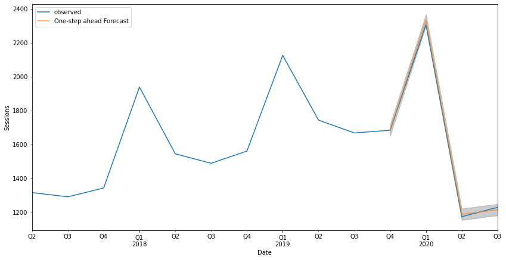

```
Root Mean Squared Error of SARIMA with season_length=4 and dynamic = True : 16.95 :
```

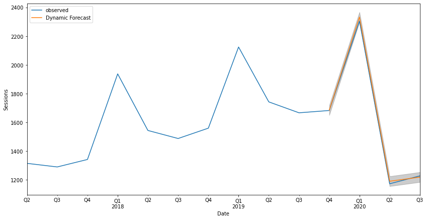

```python
model = sarima_eva(y,(0, 1, 1),(0, 1, 0, 4),4,'2019-10-31',exog=exog_pred)
```

The prediction is now very accurate - this is due to the high correlation between 'WallSt' and 'Revenue'.

Now we can also see the forecast for the future point (31-10-2020):

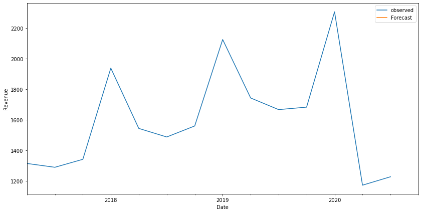

|  | Date | Predicted_Mean | Lower Bound | Upper Bound |
| --- | --- | --- | --- | --- |
| 0 | 2020-10-31 | 1535.624123 | 1502.003953 | 1569.244293 |

```python
final_table = forecast(model,y,1,exog=exog_for)
final_table.head()
```

We can observe that the predicted value for the revenue is now higher, with a much narrower confidence interval: 1536 (CI: 1502-1569). Most likely, the reason is that there has been a rebound of the economy in the 2nd half of 2020, which (theoretically) should allow a partial recovery of the revenues.

#### This prediction only works if the following assumption is true:

The 'WallSt' index is representing well the real economy - and since the 'Revenue' depends on the behaviour of the real economy, it make sense to use WallSt to predict the Revenue.

#### Of course, due to the unprecedent nature of the COVID-19 crisis, this assumption (and therefore, the prediction) must be taken with a "grain of salt".

## Approach 2: linear regression

Since we have the values of most features for the 31-10-2020 data point, we can also treat this situation as a simple machine learning problem, in which we have N known features and we want to predict the value of the target variables (Revenue).

In this case, the drawback is that we are losing the "temporal" information, since we are treating each data point as independent from the others (but in reality, they are part of a time series). Anyway, it's good to cross-check predictions using a different approach.

#### This case falls under situation B (Prediction USING information from 31-10-2020)

We'll use 2 linear regression models:

- 1) Linear regression using only 'WallSt' as independent variable
- 2) Linear regression using all features

#### 1) Using only 'WallSt' as independent variable

```python
#df = pd.read_csv("ULTA data (1).csv")#index_col=' Period Ending ',parse_dates=True)
df = pd.read_csv("../input/my-ulta/ULTA data (1).csv",engine="python")

df.drop(df.loc[:3].index,inplace=True)
df.drop(df.loc[19:].index,inplace=True)

df.drop(df.loc[:, 'IG Likes':].columns,axis=1,inplace=True)
df.drop(df.loc[:, ' COGS ':'Inventory'].columns,axis=1,inplace=True)
df.drop([' Period Ending '],axis=1,inplace=True)
df.drop(['FloorSpace'],axis=1,inplace=True)

df['COVID19'] = df['COVID19'].apply(lambda x: float(x.replace(' ','').replace(',','')))
df['WallSt'] = df['WallSt'].apply(lambda x: float(x.replace(' ','').replace(',','')))
df['WallStHigh'] = df['WallStHigh'].apply(lambda x: float(x.replace(' ','').replace(',','')))
df['WallStLow'] = df['WallStLow'].apply(lambda x: float(x.replace(' ','').replace(',','')))
```

We will use the data point up to 2019-07-31 as train dataset, then the next 4 data points as validation set - while the last data point (2020-10-31) will only be used for the final prediction

```python
df.reset_index(inplace=True)
df.drop(['index'],axis=1,inplace=True)
train = df[:10]
val = df[10:14] #use last 4 data points as validation set
test = df[14:] #last data point is used for final forecast
```

```python
train['Revenue'] = train[' Revenue '].apply(lambda x: float(x.replace(' ','').replace(',','')))
train.drop([' Revenue '],axis=1,inplace=True)
val['Revenue'] = val[' Revenue '].apply(lambda x: float(x.replace(' ','').replace(',','')))
val.drop([' Revenue '],axis=1,inplace=True)
test.drop([' Revenue '],axis=1,inplace=True)
```

We use only 'WallSt' as independent variable, and Revenue as target variable

```python
X_train = np.array(train['WallSt']).reshape(-1, 1)
y_train = train['Revenue']

X_val = np.array(val['WallSt']).reshape(-1, 1)
y_val = val['Revenue']

X_test = np.array(test['WallSt']).reshape(-1, 1)
```

```python
from sklearn.linear_model import LinearRegression

lm = LinearRegression()
lm.fit(X_train,y_train)
predictions = lm.predict(X_val)

from sklearn import metrics

print('RMSE:', np.sqrt(metrics.mean_squared_error(y_val, predictions)))
```

```
RMSE: 23.379682618963777
```

```python
df_pred = pd.concat([y_val.reset_index(), pd.Series(predictions).rename('Predictions')], axis=1)
df_pred
```

|  | index | Revenue | Predictions |
| --- | --- | --- | --- |
| 0 | 10 | 1683.0 | 1694.968509 |
| 1 | 11 | 2306.0 | 2319.435262 |
| 2 | 12 | 1173.0 | 1211.351513 |
| 3 | 13 | 1228.0 | 1247.795156 |

Predictions for the validation dataset are quite accurate (as expected, given the high correlation between WallSt and Revenue).

Now we can predict the revenue value for the 31-10-2020 data point (test dataset):

```python
pred = lm.predict(X_test)
pred
```

```
array([1559.04356936])
```

The predicted value for the 31-10-2020 revenue is 1559 - we can see it's quite compatible with the value predicted by the SARIMAX method (1536 ,CI: 1502-1569)

#### 2) Linear regression using all features:

We can try to include other features in the model - in fact, some of them also show high correlation with the target variable (revenue):

```python
train.corr()['Revenue']
```

```
 Quarter             0.567289
Unemployment        -0.560950
RetailSales          0.351651
PMI                  0.140390
GDP                  0.600925
FedInterest          0.633723
MichiganCS          -0.162041
StockPrice           0.297531
ShopCount            0.608455
COVID19                   NaN
WallSt               0.998390
WallStHigh           0.997972
WallStLow            0.996953
 Search 1 global    -0.297545
 search 2 global     0.607975
 search 3 global     0.470890
 search 4 global     0.945855
 search 1 US         0.948457
search 2 US          0.484629
search 3 US          0.926095
search 4 US          0.693413
Revenue              1.000000
Name: Revenue, dtype: float64
```

```python
X_train = train.drop(['Revenue'],axis=1)#np.array(train['WallSt']).reshape(-1, 1)
y_train = train['Revenue']

X_val = val.drop(['Revenue'],axis=1)#np.array(val['WallSt']).reshape(-1, 1)
y_val = val['Revenue']

X_test = test#np.array(test['WallSt']).reshape(-1, 1)
```

Predictions of the validation dataset (for the period 31-10-2019 to 31-07-2020):

```python
lm = LinearRegression()
lm.fit(X_train,y_train)
predictions = lm.predict(X_val)

print('RMSE:', np.sqrt(metrics.mean_squared_error(y_val, predictions)))
```

```
RMSE: 55.55297053841467
```

```python
df_pred = pd.concat([y_val.reset_index(), pd.Series(predictions).rename('Predictions')], axis=1)
df_pred
```

|  | index | Revenue | Predictions |
| --- | --- | --- | --- |
| 0 | 10 | 1683.0 | 1590.804607 |
| 1 | 11 | 2306.0 | 2341.914123 |
| 2 | 12 | 1173.0 | 1124.714510 |
| 3 | 13 | 1228.0 | 1242.940780 |

Prediction for the 31-10-2020 data point:

```python
pred = lm.predict(X_test)
pred
```

```
array([1462.14662756])
```

In this case, predictions are less accurate (in fact, RMSE increases from 23 to 55): the performances of the model seem to deteriorate if we use more features. This is a signal of overfitting: with so few data points, adding complexity into the models doesn't give better results - therefore, given that results were already good using model 1), it's probably better to keep only 'WallSt' as independent variable.

## Approach 3: Use RNN (LSTM) for multivariate time series forecast

We can also try to use a Recurrent Neural Network, which will take information from all features (in the form of time series) and their correlations to predict future values for each time series. In this case, we won't use any values from the 31-10-2020 data point - so this is a true 'blind' prediction into the future.

The main drawback here is that we only have about 15 data points, while neural networks usually require much more statistics, so again, these results should be taken with a pinch of salt.

#### This case falls under situation A (Prediction using NO information from 31-10-2020)

```python
df = pd.read_csv("../input/my-ulta/ULTA data (1).csv",engine="python")

df.drop(df.loc[18:].index,inplace=True)
df.drop(df.loc[:3].index,inplace=True) #remove 2016 data
df.drop(df.loc[:, 'IG Likes':].columns,axis=1,inplace=True)

df['Date'] = pd.to_datetime(df[' Period Ending '])
df = df.set_index('Date')
df.drop([' Period Ending '],axis=1,inplace=True)

df['Revenue'] = df[' Revenue '].apply(lambda x: float(x.replace(' ','').replace(',','')))
df['COGS'] = df[' COGS '].apply(lambda x: float(x.replace(' ','').replace(',','')))
df['COVID19'] = df['COVID19'].apply(lambda x: float(x.replace(' ','').replace(',','')))
df['WallSt'] = df['WallSt'].apply(lambda x: float(x.replace(' ','').replace(',','')))
df['WallStHigh'] = df['WallStHigh'].apply(lambda x: float(x.replace(' ','').replace(',','')))
df['WallStLow'] = df['WallStLow'].apply(lambda x: float(x.replace(' ','').replace(',','')))

df.drop([' Revenue '],axis=1,inplace=True)
df.drop([' COGS '],axis=1,inplace=True)
```

```python
from tensorflow.keras.preprocessing.sequence import TimeseriesGenerator
from tensorflow.keras.models import Sequential
from tensorflow.keras.layers import Dense
from tensorflow.keras.layers import LSTM
```

We use the last 4 data samples as "test", to compare the predictions of the model to the true values

```python
test_quarters = 4
test_ind = test_quarters*1

train = df.iloc[:-test_ind]
test = df.iloc[-test_ind:]
```

In this case, we need to scale the features:

```python
from sklearn.preprocessing import MinMaxScaler

scaler = MinMaxScaler()
scaler.fit(train)

scaled_train = scaler.transform(train)
scaled_test = scaler.transform(test)
```

```python
scaled_test.shape
```

```
(4, 28)
```

```python
length = 4 # Length of the output sequences (in number of timesteps)
batch_size = 1 #Number of timeseries samples in each batch
generator = TimeseriesGenerator(scaled_train, scaled_train, length=length, batch_size=batch_size)
```

We will use 4 layers of LSTM units (probably an overkill, but since we have very few data points, it just takes a few seconds to run)

```python
# define model
model = Sequential()

# 4 stacked layers
model.add(LSTM(256,input_shape=(length,scaled_train.shape[1]),return_sequences=True))
model.add(LSTM(256,return_sequences=True))
model.add(LSTM(256,return_sequences=True))
model.add(LSTM(256))

# Final Prediction (one neuron per feature)
model.add(Dense(scaled_train.shape[1]))

model.compile(optimizer='adam', loss='mse')

model.summary()
```

```
Model: "sequential"
_________________________________________________________________
Layer (type)                 Output Shape              Param #
=================================================================
lstm (LSTM)                  (None, 4, 256)            291840
_________________________________________________________________
lstm_1 (LSTM)                (None, 4, 256)            525312
_________________________________________________________________
lstm_2 (LSTM)                (None, 4, 256)            525312
_________________________________________________________________
lstm_3 (LSTM)                (None, 256)               525312
_________________________________________________________________
dense (Dense)                (None, 28)                7196
=================================================================
Total params: 1,874,972
Trainable params: 1,874,972
Non-trainable params: 0
_________________________________________________________________
```

```python
# fit the model
model.fit_generator(generator,epochs=100)
```

```
<tensorflow.python.keras.callbacks.History at 0x7f50b52f5950>
```

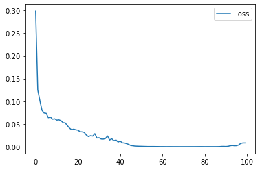

```python
losses = pd.DataFrame(model.history.history)
losses.plot()
```

(could have stopped after less epochs - however it won't make much difference for the final prediction)

### In-sample prediction

Now we use the model to predict the Revenue for the last 4 data points - and then compare the predictions to the true values:

```python
n_features = scaled_train.shape[1]
test_predictions = []

first_eval_batch = scaled_train[-length:]
current_batch = first_eval_batch.reshape((1, length, n_features))

for i in range(len(test)):

    # get prediction 1 time stamp ahead ([0] is for grabbing just the number instead of [array])
    current_pred = model.predict(current_batch)[0]

    # store prediction
    test_predictions.append(current_pred)

    # update batch to now include prediction and drop first value
    current_batch = np.append(current_batch[:,1:,:],[[current_pred]],axis=1)
```

```python
true_predictions = scaler.inverse_transform(test_predictions)
true_predictions = pd.DataFrame(data=true_predictions,index=test.index,columns=test.columns)
true_predictions.head()
```

| Date | Quarter | GrossProfit | NetIncome | DilutedEPS | Inventory | Unemployment | RetailSales | PMI | GDP | FedInterest | ... | Search 1 global | search 2 global | search 3 global | search 4 global | search 1 US | search 2 US | search 3 US | search 4 US | Revenue | COGS |
| --- | --- | --- | --- | --- | --- | --- | --- | --- | --- | --- | --- | --- | --- | --- | --- | --- | --- | --- | --- | --- | --- |
| 2019-10-31 | 2.382691 | 606.151241 | 164.117151 | 2.771706 | 1285.719522 | 3.680378 | 146.788556 | 50.012452 | 189.789154 | 2.366386 | ... | 1.881022 | 2.282130 | 3.286936 | 46.890985 | 42.145288 | 3.265536 | 5.638076 | 2.365342 | 1719.592239 | 1121.675546 |
| 2020-01-31 | 3.998396 | 726.350124 | 229.411787 | 3.732597 | 1109.441977 | 3.858364 | 127.988060 | 53.866522 | 184.036330 | 2.410001 | ... | 2.394590 | 3.445356 | 3.195269 | 60.245111 | 58.178907 | 3.110447 | 6.542969 | 3.445785 | 2145.556353 | 1436.844405 |
| 2020-04-30 | 2.025832 | 655.684457 | 205.812195 | 3.415738 | 1183.030428 | 3.719299 | 144.843256 | 50.697676 | 194.884244 | 2.678128 | ... | 2.031578 | 2.372029 | 2.949988 | 50.211780 | 45.497347 | 2.851131 | 6.024203 | 2.361916 | 1878.940210 | 1232.706529 |
| 2020-07-31 | 2.157861 | 609.830935 | 171.262713 | 2.930222 | 1233.313238 | 3.663256 | 150.903379 | 49.032189 | 191.792405 | 2.466307 | ... | 1.836948 | 2.246334 | 3.314760 | 47.931100 | 42.402027 | 3.242642 | 5.778801 | 2.281608 | 1748.889228 | 1138.430562 |

4 rows × 28 columns

```python
predictions = pd.concat([train,true_predictions],axis=0)
```

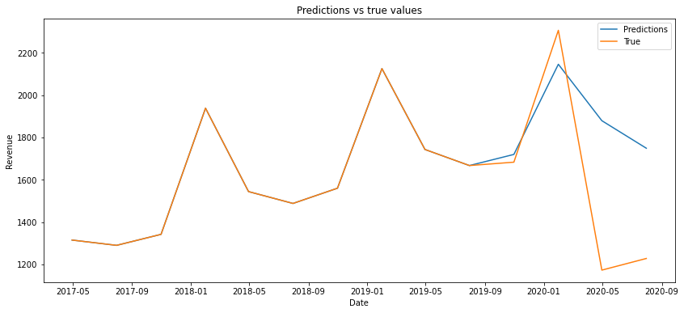

```python
def make_plots(var='Revenue',date='2016-07-31'):
    fig, ax = plt.subplots(figsize=(14,6))

    ax.set_xlabel('Date')
    ax.set_ylabel(var)
    ax.plot(df.loc[date:].index, predictions.loc[date:][var], label='Predictions')
    ax.plot(df.loc[date:].index, df.loc[date:][var], label='True')
    #ax.tick_params(axis='y', labelcolor=color)

    legend = ax.legend()

#    fig.tight_layout()
    plt.title('Predictions vs true values')
    plt.show()

make_plots()
```

Results seem less accurate than SARIMA, although they look OK-ish for the first 1-2 data points.

### Future forecast (31-10-2020)

Now we re-fit the model using the entire train dataset, and we use it to forecast the value of the Revenue series for the missing data point (31-10-2020)

```python
full_scaler = MinMaxScaler()
scaled_full_data = full_scaler.fit_transform(df)

length = 4 # Length of the output sequences (in number of timesteps)
generator = TimeseriesGenerator(scaled_full_data, scaled_full_data, length=length, batch_size=1)
```

```python
model = Sequential()

# 4 stacked layers
model.add(LSTM(256,input_shape=(length,scaled_full_data.shape[1]),return_sequences=True))
model.add(LSTM(256,return_sequences=True))
model.add(LSTM(256,return_sequences=True))
model.add(LSTM(256))

# Final Prediction (one neuron per feature)
model.add(Dense(scaled_full_data.shape[1]))

model.compile(optimizer='adam', loss='mse')

model.fit_generator(generator,epochs=100)
```

```
<tensorflow.python.keras.callbacks.History at 0x7f5037963b10>
```

```python
forecast = []
periods = 4

first_eval_batch = scaled_full_data[-length:]
current_batch = first_eval_batch.reshape((1, length, n_features))

for i in range(periods):

    # get prediction 1 time stamp ahead ([0] is for grabbing just the number instead of [array])
    current_pred = model.predict(current_batch)[0]

    # store prediction
    forecast.append(current_pred)

    # update batch to now include prediction and drop first value
    current_batch = np.append(current_batch[:,1:,:],[[current_pred]],axis=1)
```

```python
forecast = full_scaler.inverse_transform(forecast)
forecast_index = pd.date_range(start='2020-10-31',periods=periods,freq='Q-OCT')
true_predictions = pd.DataFrame(data=forecast,index=forecast_index,columns=df.columns)
true_predictions.head()
```

|  | Quarter | GrossProfit | NetIncome | DilutedEPS | Inventory | Unemployment | RetailSales | PMI | GDP | FedInterest | ... | Search 1 global | search 2 global | search 3 global | search 4 global | search 1 US | search 2 US | search 3 US | search 4 US | Revenue | COGS |
| --- | --- | --- | --- | --- | --- | --- | --- | --- | --- | --- | --- | --- | --- | --- | --- | --- | --- | --- | --- | --- | --- |
| 2020-10-31 | 2.148641 | 363.754714 | 61.485599 | 1.095445 | 1405.791323 | 12.227206 | 139.368928 | 47.111463 | 125.380873 | 0.147254 | ... | 1.993904 | 2.148796 | 3.149402 | 51.072427 | 44.869498 | 3.331093 | 6.878398 | 1.986006 | 1233.398195 | 909.649440 |
| 2021-01-31 | 2.749803 | 483.905601 | 36.308916 | 0.981907 | 1692.631631 | 7.525727 | 174.569244 | 48.810529 | 178.741262 | 0.945511 | ... | 2.058594 | 2.021666 | 2.999781 | 47.958874 | 40.301047 | 2.968828 | 7.088470 | 2.019871 | 1351.079162 | 990.344151 |
| 2021-04-30 | 2.075018 | 342.149984 | 62.263693 | 1.100599 | 1354.223365 | 12.762196 | 133.039498 | 46.970243 | 117.854338 | 0.083874 | ... | 1.989533 | 2.158957 | 3.132574 | 51.237563 | 45.209964 | 3.362090 | 6.754450 | 2.006257 | 1251.054942 | 895.029094 |
| 2021-07-31 | 2.147481 | 352.202649 | 66.841290 | 1.171361 | 1368.523982 | 12.832724 | 132.161514 | 47.082394 | 117.076461 | 0.068103 | ... | 1.986510 | 2.171867 | 3.180548 | 51.565473 | 45.517603 | 3.405485 | 6.867319 | 2.013637 | 1250.513707 | 898.333579 |

4 rows × 28 columns

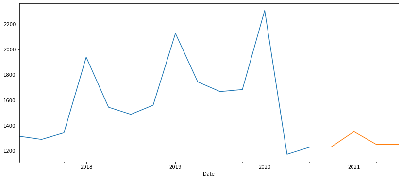

```python
plt.figure(figsize=(14,6))
ax = df['Revenue'].plot()
true_predictions['Revenue'].plot(ax=ax)
```

```python
true_predictions['Revenue'].loc['2020-10-31']
```

```
1233.398194923997
```

The predicted value for the revenue (1233) is very similar to that of the SARIMA model (1244.0, C.I: 742-1746).

# Conclusions

At a first glance, the 3 approaches seem to give different results - however, it's quite the opposite. In fact, we need to distinguish between the 2 different situations:

A) Prediction of 31-10-2020 revenue using NO information from 31-10-2020. In this case, the two models used give a similar prediction for the revenue:

- SARIMA: 1244.0 (C.I: 742-1746)
- LSTM: 1233

B) Prediction of 31-10-2020 revenue USING information from 31-10-2020. Here again the two models used give a similar prediction:

- SARIMA(X) + Exogeneous variable: 1536 (CI: 1502-1569)
- Linear regression: 1559

In case 2, the predicted value for the revenue is higher - this is due to the fact that we observed a partial 'rebound' in the economy in the last period, as we can see in the 'WallSt' variable - so if we use this additional piece of information in our model, we get a more optimistic prediction.

In conclusion: when predicting the revenue value for a certain data point, IF additional info about that data point are known (as in this case), situation B gives better results and should be preferred. If this is not the case, then only situation A can be used.